# Household Carbon Footprint Analysis

Laura Osei-Mensah

Project Overview

This project investigates factors associated with household carbon footprint and recycling behaviour using R. The analysis combines exploratory data analysis, data visualisation and statistical modelling to examine relationships between household characteristics, environmental behaviours and carbon footprint.

The project addresses two main questions:

Which household characteristics are associated with carbon footprint?

Which factors are associated with the likelihood of regularly recycling?

```r
library(ggplot2)
library(tidyverse)
library(mgcv)
library(car)
```

# 1. Load dataset

Data availability: The dataset used for this analysis was provided as part of an academic assessment and is not included in this public repository. The analysis below uses the assigned sample from the original dataset and demonstrates the data cleaning, exploratory analysis and statistical modelling undertaken as part of the project.

```r
carbon <- read.csv("carbon.csv")
```

## 1.2 Data quality plan

To assess the quality of the data, I reviewed all variables against the metadata to confirm their definitions, datatypes and relevance to the analysis, and to identify any inconsistencies or contradictions within the data set.

The household_size and number_adults variables were examined to ensure all values were integers, to assess missing values, and to identify unrealistic values such as negative numbers or extreme outliers that could indicate data entry errors.

The annual_energy_consumption and carbon_footprint variables were checked for missing values, and to confirm that observations fell within the ranged specified by the metadata.

The income variable was assessed for missingness, negative values and extreme outliers that may indicate data quality issues.

The environmental_concern_score variable was examined for missing values, to confirm that all values were integers, and to ensure that values fell into the range specified in the metadata.

The binary variables recycles_regularly, uses_public_transport and recycles_regularly_question were checked for missingness and verified to contain only binary values, as defined in the metadata.

Finally, categorical variables diet_type and home_type was checked for missingness, spelling errors, and that there were four different categories within both columns as observed in the metadata.

## 1.3 Data quality findings

### Issue 1

When the home_type variable was initially converted to a factor, eight levels were observed, whereas the metadata indicated four levels should be present. I therefore investigated each unique observation within the variable and found that several categories were duplicated due to wording variations for example “Terraced” and “Terrace”.

To correct this, I temporary treated the variable as a character to re-code the category labels and avoid constraints imposed by existing factor levels.

```r
# unique function to view each distinct observation (R Programming 101,2021)
unique(carbon$home_type)
```

```
## [1] "Flat"          "Detached"      "Semi-detached" "Terraced"
## [5] "flat"          "Terrrace"      "semi-detached" "detatched"
```

### Issue 2

```r
summary(carbon)
```

```
##  household_size  annual_energy_consumption recycles_regularly
##  Min.   :1.000   Min.   :-650              Min.   :0.0000
##  1st Qu.:1.000   1st Qu.:3810              1st Qu.:0.0000
##  Median :2.000   Median :4453              Median :1.0000
##  Mean   :2.608   Mean   :4399              Mean   :0.5958
##  3rd Qu.:3.000   3rd Qu.:5098              3rd Qu.:1.0000
##  Max.   :8.000   Max.   :7067              Max.   :1.0000
##
##  uses_public_transport  diet_type         carbon_footprint
##  Length:240            Length:240         Min.   : 3945
##  Class :character      Class :character   1st Qu.: 9492
##  Mode  :character      Mode  :character   Median :11201
##                                           Mean   :11095
##                                           3rd Qu.:12518
##                                           Max.   :15000
##
##  environmental_concern_score     income      number_adults    home_type
##  Min.   : 1.000              Min.   : 3251   Min.   :0.000   Length:240
##  1st Qu.: 5.000              1st Qu.:12224   1st Qu.:1.000   Class :character
##  Median : 6.000              Median :18257   Median :2.000   Mode  :character
##  Mean   : 6.083              Mean   :22104   Mean   :2.546
##  3rd Qu.: 7.000              3rd Qu.:28076   3rd Qu.:3.000
##  Max.   :10.000              Max.   :93562   Max.   :8.000
##                              NA's   :22
##  recycles_regularly_question
##  Length:240
##  Class :character
##  Mode  :character
##
##
##
##
```

```r
carbon %>%
  filter(annual_energy_consumption < 1000) # (R Programming 101,2021)
```

```
##   household_size annual_energy_consumption recycles_regularly
## 1              2                      -500                  1
## 2              2                      -500                  1
## 3              1                      -650                  0
## 4              2                      -650                  0
##   uses_public_transport   diet_type carbon_footprint
## 1                   Yes Pescatarian          10334.6
## 2                   Yes Pescatarian          12095.7
## 3                    No    Omnivore          15000.0
## 4                   Yes    Omnivore           8780.1
##   environmental_concern_score   income number_adults home_type
## 1                           7       NA             2      Flat
## 2                           8       NA             2      Flat
## 3                           4 78302.01             1  Terraced
## 4                           5 18208.39             2      Flat
##   recycles_regularly_question
## 1                         Yes
## 2                         Yes
## 3                          No
## 4                          No
```

### Issue 3

To check for missing values across the data set, I examined the number of NAs in each column. I found that income was the only variable containing missing values. I then filtered the data to identify where the missing entries occurred, and confirmed that the other variables appeared to be complete

```r
colSums(is.na(carbon))
```

```
##              household_size   annual_energy_consumption
##                           0                           0
##          recycles_regularly       uses_public_transport
##                           0                           0
##                   diet_type            carbon_footprint
##                           0                           0
## environmental_concern_score                      income
##                           0                          22
##               number_adults                   home_type
##                           0                           0
## recycles_regularly_question
##                           0
```

```r
carbon %>%
  filter(!complete.cases(.)) # To show the missing values within the data set (R Programming 101,2021)
```

```
##    household_size annual_energy_consumption recycles_regularly
## 1               2                    4816.5                  0
## 2               1                    4454.5                  1
## 3               1                    4211.0                  1
## 4               1                    4479.5                  0
## 5               2                    4255.7                  1
## 6               2                    3270.2                  1
## 7               2                    2969.6                  1
## 8               6                    6698.1                  1
## 9               6                    6718.8                  0
## 10              2                    3838.7                  0
## 11              4                    4853.2                  0
## 12              1                    3741.0                  0
## 13              1                    3602.7                  1
## 14              5                    5389.1                  1
```

[output cut: 77 more lines]

## 1.4 Data cleaning

### Addressing Issue 1

To address Issue 1, I used the ifelse() function to resolve the duplicated observation categories. All observations labelled “Terrace” were change to “Terraced”, “flat” to “Flat”, “detached” to “Detached” and “semi-detached” to “Semi-detached”.

This approach was justified as it ensures consistency within categorical variables, which is essential for accurate grouping and analysis. I considered using mutate function but because corrections were not complex and required simple conditional replacements, I found ifelse() to be sufficient.

```r
# Creating a new variable with corrections
carbon$home_type <- ifelse(carbon$home_type == "Terrrace", "Terraced",
                            ifelse(carbon$home_type == "flat", "Flat",
                              ifelse(carbon$home_type == "detatched","Detached",
                                     ifelse(carbon$home_type == "semi-detached", "Semi-detached",                                              carbon$home_type))))

# Checking the observations within home_type variable
unique(carbon$home_type)
```

```
## [1] "Flat"          "Detached"      "Semi-detached" "Terraced"
```

### Addressing Issue 2

For issue 2, I created a new variable that contained the data frame with the four rows where annual_energy_consumption had negative values removed.This approach was used because the number of affected rows were small and retaining invalid values could bias the analysis. An alternative approach would’ve been to impute values using the mean or median, but this could have distorted the relationship between variables.

```r
carbon_ann_rmv <- carbon %>%
  filter(annual_energy_consumption > 0)
```

### Addressing Issue 3

To address issue 3, I created a new variable with all NA values removed. This was necessary for logistic regression, which required complete cases. The carbon_ann-rmv dataset was retained for multiple regression using the step function, as it can handle NAs without requiring row removal.

```r
carbon_no_na <- carbon_ann_rmv[complete.cases(carbon_ann_rmv),]
```

# 2. Exploratory Data Analysis (EDA)

The variables carbon_footprint and recycles_regularly were central to my analysis. I examined the distribution of carbon footprint using histograms to assess shape and outliers. Relationships with numerical variables were explored using a Generalised Additive Model (GAM), correlations, scatter plots, and a regression tree, while associations with categorical variables were examined using boxplots and t-tests. Recycling behaviour was analysed using frequency comparisons, t-tests, aggregate functions, chi-squared tests, a mosaic plot.

### Element 1

I used Spearman’s rank correlation to assess associations between numerical variables and carbon footprint.

```r
# Putting the numeric variables in carbon_num variable
carbon_num <- carbon_ann_rmv %>%
  select(household_size, annual_energy_consumption,carbon_footprint,environmental_concern_score,income,number_adults)

cor(carbon_num, method = "spearman", use="complete.obs")
```

```
##                             household_size annual_energy_consumption
## household_size                  1.00000000                0.48171964
## annual_energy_consumption       0.48171964                1.00000000
## carbon_footprint                0.36133403                0.75920822
## environmental_concern_score     0.05764338               -0.01224382
## income                          0.03153520               -0.02190073
## number_adults                   0.99421195                0.48810269
##                             carbon_footprint environmental_concern_score
## household_size                     0.3613340                  0.05764338
## annual_energy_consumption          0.7592082                 -0.01224382
## carbon_footprint                   1.0000000                  0.01830020
## environmental_concern_score        0.0183002                  1.00000000
## income                             0.5175557                  0.04193014
## number_adults                      0.3737770                  0.05038324
##                                  income number_adults
## household_size               0.03153520    0.99421195
## annual_energy_consumption   -0.02190073    0.48810269
## carbon_footprint             0.51755570    0.37377700
## environmental_concern_score  0.04193014    0.05038324
## income                       1.00000000    0.03832203
## number_adults                0.03832203    1.00000000
```

The results indicate a strong positive correlation (0.76) between carbon footprint and annual energy consumption, suggesting households with higher energy use tend to have larger carbon footprints.A moderately strong correlation between carbon footprint and income (0.51), indicating that higher income is associated with increased carbon emissions.

Additionally, a strong correlation was identified between household size and number of adults (0.99), suggesting multicollinearity between these variables. Therefore only one of these variables were used in my model, Overall, the analysis was informative as it highlighted key drivers of carbon footprint and guided variable selection.

### Element 2

I used a GAM to examine potential non-linear relationships between carbon footprint and key numerical explanatory variables. Household size, number of adults, and environmental concern score were excluded as smooth terms because their limited discrete ranges made smoothing inappropriate.

```r
gam_model <- gam(carbon_footprint ~ s(income) + s(annual_energy_consumption),data = carbon_ann_rmv)
summary(gam_model)
```

```
##
## Family: gaussian
## Link function: identity
##
## Formula:
## carbon_footprint ~ s(income) + s(annual_energy_consumption)
##
## Parametric coefficients:
##             Estimate Std. Error t value Pr(>|t|)
## (Intercept) 11111.71      38.67   287.4   <2e-16 ***
## ---
## Signif. codes:  0 '***' 0.001 '**' 0.01 '*' 0.05 '.' 0.1 ' ' 1
##
## Approximate significance of smooth terms:
##                                edf Ref.df     F p-value
## s(income)                    5.947  7.100 138.0  <2e-16 ***
## s(annual_energy_consumption) 2.982  3.805 484.6  <2e-16 ***
## ---
## Signif. codes:  0 '***' 0.001 '**' 0.01 '*' 0.05 '.' 0.1 ' ' 1
##
## R-sq.(adj) =  0.928   Deviance explained = 93.1%
## GCV = 3.3848e+05  Scale est. = 3.2292e+05  n = 216
```

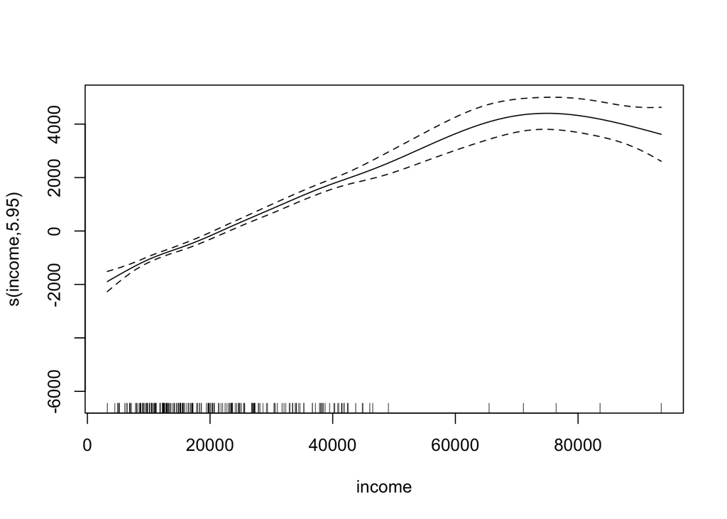

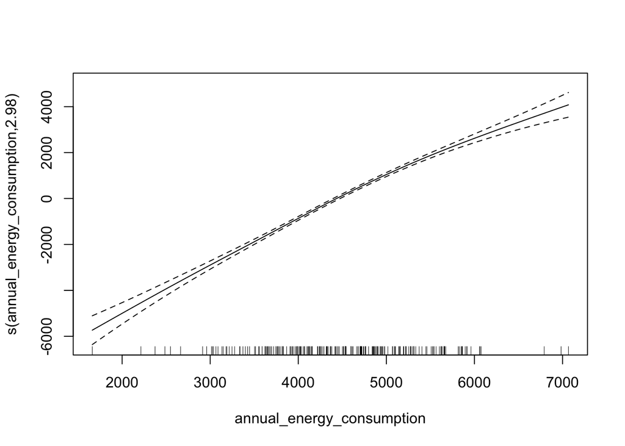

```r
plot(gam_model)
```

The income smooth suggests a moderate non-linear relationship, while annual energy consumption shows a strong near-linear effect. This analysis supports exploring quadratic terms for income and annual energy consumption in subsequent modelling.

### Element 3

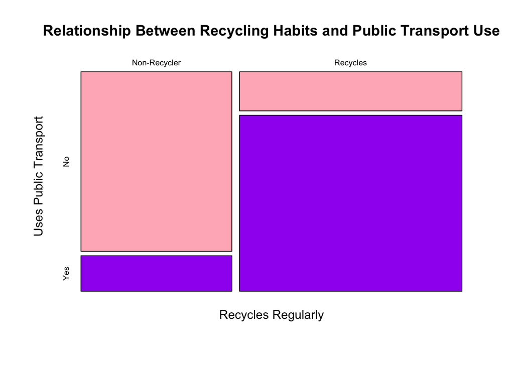

```r
# creating a new variable to rename recycling observations from Yes/No to Non-Recycler/Recycles
carbon$recyclesNew <- ifelse(carbon$recycles_regularly_question == "Yes", "Recycles","Non-Recycler")

# Mosaic plot
mosaicplot(~carbon$recyclesNew  + carbon$uses_public_transport,
           main = "Relationship Between Recycling Habits and Public Transport Use",
           xlab = "Recycles Regularly",
           ylab = "Uses Public Transport",
           color = c("lightpink", "purple"),
           data = carbon) # (Ripley,2022)
```

The mosaic plot shows individuals who recycle regularly are more likely to use public transport compared with non-recyclers.This suggests that environmentally conscious behaviours are linked, with individuals who recycle being more likely to use public transport. This visualisation is informative as it highlights patterns of association between two categorical variables that are not easily identified from summary tables alone.

# 3. Modelling

I used multiple linear regression with step wise model selection to obtain a minimum adequate model, identifying explanatory variables that significantly influence carbon footprint while removing unnecessary complexity.

## Model for carbon_footprint.

### Initial Model

```r
# creating a new variable for environmental_concern_score
carbon_ann_rmv$score.group <- ifelse(carbon_ann_rmv$environmental_concern_score <=4, "Low",
                             ifelse(carbon_ann_rmv$environmental_concern_score < 8, "Medium", "High"))

# changing the below into factor variable before using in my model
carbon_ann_rmv$score.group <- factor((carbon_ann_rmv$score.group),
                             levels = c("High","Medium", "Low"))
carbon_ann_rmv$home_type <- as.factor(carbon_ann_rmv$home_type)
carbon_ann_rmv$uses_public_transport <- as.factor(carbon_ann_rmv$uses_public_transport)
carbon_ann_rmv$diet_type <- as.factor(carbon_ann_rmv$diet_type)
carbon_ann_rmv$recycles_regularly_question <- as.factor(carbon_ann_rmv$recycles_regularly_question)

# starting model

carbon.model1 <- lm(carbon_footprint~annual_energy_consumption*income + I(annual_energy_consumption^2) + I(income^2) + household_size*annual_energy_consumption + recycles_regularly_question + uses_public_transport + diet_type + score.group + home_type, data = carbon_ann_rmv)
```

### Proposed model

```r
carbon.model2 <- step(carbon.model1)
```

```
## Start:  AIC=2738.43
## carbon_footprint ~ annual_energy_consumption * income + I(annual_energy_consumption^2) +
##     I(income^2) + household_size * annual_energy_consumption +
##     recycles_regularly_question + uses_public_transport + diet_type +
##     score.group + home_type
##
##                                            Df Sum of Sq      RSS    AIC
## - home_type                                 3    552653 59168164 2734.4
## - diet_type                                 3    686377 59301888 2734.9
## - score.group                               2    165270 58780781 2735.0
## - uses_public_transport                     1      1940 58617451 2736.4
## - annual_energy_consumption:household_size  1     71269 58686780 2736.7
## - recycles_regularly_question               1    194114 58809625 2737.1
## <none>                                                  58615511 2738.4
## - I(annual_energy_consumption^2)            1   1298026 59913537 2741.2
## - I(income^2)                               1   8644703 67260214 2766.1
## - annual_energy_consumption:income          1   9125064 67740575 2767.7
##
## Step:  AIC=2734.45
## carbon_footprint ~ annual_energy_consumption + income + I(annual_energy_consumption^2) +
##     I(income^2) + household_size + recycles_regularly_question +
##     uses_public_transport + diet_type + score.group + annual_energy_consumption:income +
##     annual_energy_consumption:household_size
##
##                                            Df Sum of Sq      RSS    AIC
## - diet_type                                 3    625673 59793837 2730.7
## - score.group                               2    259152 59427317 2731.4
## - uses_public_transport                     1      5444 59173609 2732.5
## - annual_energy_consumption:household_size  1     80305 59248469 2732.8
## - recycles_regularly_question               1    318441 59486605 2733.6
## <none>                                                  59168164 2734.4
## - I(annual_energy_consumption^2)            1   1179306 60347470 2736.7
## - I(income^2)                               1   8724564 67892728 2762.2
## - annual_energy_consumption:income          1   9534434 68702598 2764.7
##
## Step:  AIC=2730.73
## carbon_footprint ~ annual_energy_consumption + income + I(annual_energy_consumption^2) +
##     I(income^2) + household_size + recycles_regularly_question +
##     uses_public_transport + score.group + annual_energy_consumption:income +
##     annual_energy_consumption:household_size
```

[output cut: 58 more lines]

```
## - household_size                    1    495446 60920902 2722.8
## <none>                                          60425455 2723.0
## - I(annual_energy_consumption^2)    1   2623956 63049411 2730.2
## - I(income^2)                       1   9105384 69530839 2751.3
## - annual_energy_consumption:income  1  10137642 70563097 2754.5
##
## Step:  AIC=2722.76
## carbon_footprint ~ annual_energy_consumption + income + I(annual_energy_consumption^2) +
##     I(income^2) + annual_energy_consumption:income
##
##                                    Df Sum of Sq      RSS    AIC
## <none>                                          60920902 2722.8
## - I(annual_energy_consumption^2)    1   3383254 64304156 2732.4
## - I(income^2)                       1   8750196 69671097 2749.8
## - annual_energy_consumption:income  1  10191825 71112726 2754.2
```

### Proposed model diagnostics

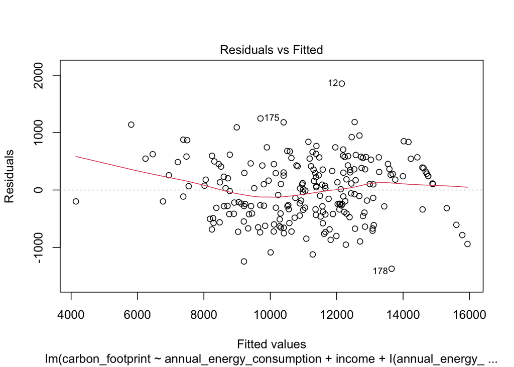

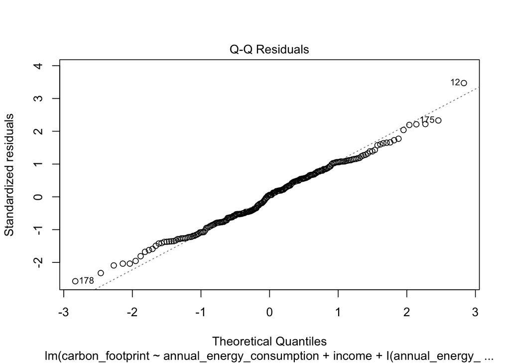

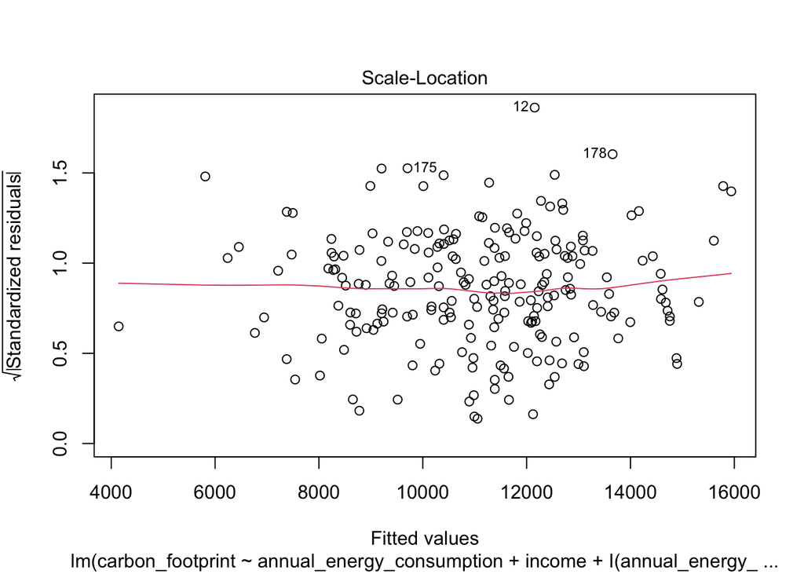

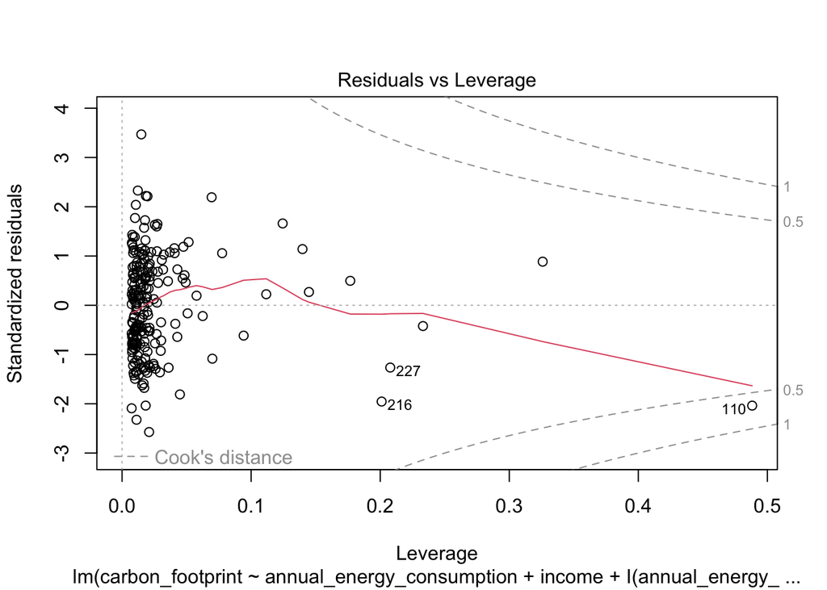

```r
plot(carbon.model2)
```

Overall, residuals are acceptable, though Q–Q plot tails deviate and the residuals-fitted plot suggests mild heteroscedasticity.

### Proposed model intepretation

```r
summary(carbon.model2)
```

```
##
## Call:
## lm(formula = carbon_footprint ~ annual_energy_consumption + income +
##     I(annual_energy_consumption^2) + I(income^2) + annual_energy_consumption:income,
##     data = carbon_ann_rmv)
##
## Residuals:
##      Min       1Q   Median       3Q      Max
## -1371.21  -408.34    30.01   383.69  1854.57
##
## Coefficients:
##                                    Estimate Std. Error t value Pr(>|t|)
## (Intercept)                      -3.443e+03  7.043e+02  -4.888 2.02e-06 ***
## annual_energy_consumption         3.238e+00  2.898e-01  11.173  < 2e-16 ***
## income                            2.051e-01  1.599e-02  12.825  < 2e-16 ***
## I(annual_energy_consumption^2)   -1.082e-04  3.169e-05  -3.415 0.000765 ***
## I(income^2)                      -5.284e-07  9.621e-08  -5.492 1.14e-07 ***
## annual_energy_consumption:income -1.875e-05  3.163e-06  -5.927 1.25e-08 ***
## ---
## Signif. codes:  0 '***' 0.001 '**' 0.01 '*' 0.05 '.' 0.1 ' ' 1
##
## Residual standard error: 538.6 on 210 degrees of freedom
##   (20 observations deleted due to missingness)
## Multiple R-squared:  0.9367, Adjusted R-squared:  0.9352
## F-statistic: 621.7 on 5 and 210 DF,  p-value: < 2.2e-16
```

The adjusted R squared is 0.94, indicating the model explains 94% of the variation in carbon footprint. All predictors are statistically significant. Energy consumption and income increase carbon footprint, but their negative quadratic terms suggest a decreasing effect. Interaction between energy consumption and income has a decreasing effect on carbon footprint. I found this model appropriate because it explains a large proportion of the variance while being less complex than Model 1, achieving a good balance between simplicity and explanatory power.

# 4. Model the likelihood of being a household that regularly recycles.

A limitation of the model is the relatively small sample size (around 240 observations), which may limit statistical power and affect the stability of coefficient estimates. Also, the data are the model identifies associations rather than causal effects.

### Proposed Model

```r
# Using the data set stored in the carbon variable that has no rows removed

# creating a new variable for environmental_concern_score
carbon$score.group <- ifelse(carbon$environmental_concern_score <=4, "Low",
                             ifelse(carbon$environmental_concern_score < 8, "Medium", "High"))

# changing the below into factor variable before using in my model
carbon$score.group <- factor((carbon$score.group),
                             levels = c("High","Medium", "Low"))
carbon$home_type <- as.factor(carbon$home_type)
carbon$uses_public_transport <- as.factor(carbon$uses_public_transport)
carbon$diet_type <- as.factor(carbon$diet_type)
carbon$recycles_regularly_question <- as.factor(carbon$recycles_regularly_question)

recycle.model <- step(glm(recycles_regularly~annual_energy_consumption + uses_public_transport + diet_type + carbon_footprint + score.group + home_type, family = binomial, data = carbon))
```

```
## Start:  AIC=181.03
## recycles_regularly ~ annual_energy_consumption + uses_public_transport +
##     diet_type + carbon_footprint + score.group + home_type
##
##                             Df Deviance    AIC
## - diet_type                  3   159.60 177.60
## - carbon_footprint           1   157.03 179.03
## - annual_energy_consumption  1   157.24 179.24
## <none>                           157.03 181.03
## - home_type                  3   166.24 184.24
## - uses_public_transport      1   176.16 198.16
## - score.group                2   206.35 226.35
##
## Step:  AIC=177.6
## recycles_regularly ~ annual_energy_consumption + uses_public_transport +
##     carbon_footprint + score.group + home_type
##
##                             Df Deviance    AIC
## - carbon_footprint           1   159.61 175.61
## - annual_energy_consumption  1   159.83 175.83
## <none>                           159.60 177.60
## - home_type                  3   168.60 180.60
## - uses_public_transport      1   179.37 195.37
## - score.group                2   208.39 222.39
##
## Step:  AIC=175.61
## recycles_regularly ~ annual_energy_consumption + uses_public_transport +
##     score.group + home_type
##
##                             Df Deviance    AIC
## - annual_energy_consumption  1   160.16 174.16
## <none>                           159.61 175.61
## - home_type                  3   168.72 178.72
## - uses_public_transport      1   179.48 193.48
## - score.group                2   208.50 220.50
##
## Step:  AIC=174.16
## recycles_regularly ~ uses_public_transport + score.group + home_type
##
##                         Df Deviance    AIC
## <none>                       160.16 174.16
## - home_type              3   168.74 176.74
## - uses_public_transport  1   179.48 191.48
## - score.group            2   208.89 218.89
```

### Model intepretation

```r
summary(recycle.model)
```

```
##
## Call:
## glm(formula = recycles_regularly ~ uses_public_transport + score.group +
##     home_type, family = binomial, data = carbon)
##
## Coefficients:
##                           Estimate Std. Error z value Pr(>|z|)
## (Intercept)                17.3235  1386.0150   0.012   0.9900
## uses_public_transportYes    1.7432     0.4164   4.186 2.84e-05 ***
## score.groupMedium         -18.2587  1386.0149  -0.013   0.9895
## score.groupLow            -21.3417  1386.0152  -0.015   0.9877
## home_typeFlat               1.2230     0.5607   2.181   0.0292 *
## home_typeSemi-detached      1.2445     0.5929   2.099   0.0358 *
## home_typeTerraced           0.1620     0.5274   0.307   0.7587
## ---
## Signif. codes:  0 '***' 0.001 '**' 0.01 '*' 0.05 '.' 0.1 ' ' 1
##
## (Dispersion parameter for binomial family taken to be 1)
##
##     Null deviance: 323.84  on 239  degrees of freedom
## Residual deviance: 160.16  on 233  degrees of freedom
## AIC: 174.16
##
## Number of Fisher Scoring iterations: 18
```

```r
exp(coef(recycle.model))
```

```
##              (Intercept) uses_public_transportYes        score.groupMedium
##             3.338001e+07             5.715425e+00             1.175786e-08
##           score.groupLow            home_typeFlat   home_typeSemi-detached
##             5.387715e-10             3.397266e+00             3.471089e+00
##        home_typeTerraced
##             1.175875e+00
```

```r
vif(recycle.model)
```

```
##                           GVIF Df GVIF^(1/(2*Df))
## uses_public_transport 1.122622  1        1.059539
## score.group           1.085720  2        1.020774
## home_type             1.072440  3        1.011724
```

The results indicate that use of public transport is the strongest predictor of regular recycling, with a highly significant effect. The exponentiated coefficient suggests that households using public transport are approximately 5.72 times more likely to recycle regularly compared to those who do not.

Housing type is also an important predictor. Households living in semi-detached houses are approximately 3.47 times more likely to recycle regularly than those in detached houses (the baseline category), while households living in flats are approximately 3.40 times more likely to recycle regularly.

Although score_group showed a significant association with recycling behaviour in univariate analysis, its coefficients were not statistically significant in the multivariable logistic regression model. This highlights a limitation of the model, as relationships that appear significant on their own may weaken when other predictors are included. The variable was retained by stepwise selection due to a reduction in AIC. Low VIF values indicate that multicollinearity is not a concern.